# 1st Phase

## PROBLEM STATEMENT:

#### The street dog survey dataset is a well know dataset in the field of machine learning, in data

#### analysis,it contains measurements of population of dogs in different areas in banglore.This

#### project aims to performs and in depth Exploratory Data Analysis(EDA) and Statistical Analysis

#### of the Street dog survey dataset,the dataset to gain insight into the characteristics like polulation

#### of dogs in a particular area,gender of the dogs found,the percentage of dogs neutered,howmany

#### dogs are present according to per sq.km and make us to understand the dataset and make

#### predictions that can help us later.

## Project Plan:

### Project Initiation

#### ● Define project objectives and scope.

#### ● Identify stakeholders and their expectations.

### Data Collection and Preprocessing

#### ● Explore and clean the data.

#### ● Handle missing values.

#### ● Normalize or scale features if needed.

### Data Analysis

#### ● Perform exploratory data analysis.

#### ● Visualize data distribution and correlations.

#### ● Identify potential feature selection or engineering.

### Model Development

#### ● Split the data into training and testing sets.

#### ● Implement and train various regression models (e.g., Linear Regression,

#### Decision Trees, Random Forest).

#### ● Evaluate model performance using appropriate metrics.

#### ● Fine-tune hyperparameters.

### Model Validation

#### ● Validate the model's performance on unseen data.

#### ● Cross-validation to assess model generalization.

#### ● Address any overfitting or underfitting issues.

### Documentation

#### ● Create documentation for the project, including the dataset, data

#### preprocessing steps, and model details.

#### ● Prepare a report or presentation summarizing the findings and the model's

#### performance.

### Deployment and Integration

#### ● Deploy the model to a relevant platform or system.

#### ● Integrate the model with any necessary applications or interfaces.

### Testing and Quality Assurance (Week 13)

#### ● Thoroughly test the deployed model to ensure it functions as expected.

#### ● Address any issues or bugs.

### Maintenance and Monitoring (Ongoing)

#### ● Establish a system for monitoring model performance in production.

#### ● Plan for model updates and maintenance

## Product backlog:

### Task: Data Collection

#### ● Subtask: Verify data integrity and sources.

### Task: Data Preprocessing

#### ● Subtask: Data cleaning and handling missing values.

#### ● Subtask: Normalize or scale features.

### Task: Data Analysis

#### ● Subtask: EDA - Visualize data distribution.

#### ● Subtask: EDA - Identify correlations between features.

#### ● Subtask: Feature selection and engineering.

### Task: Model Development

#### ● Subtask: Implement Linear Regression model.

#### ● Subtask: Implement Decision Trees and Random Forest models.

#### ● Subtask: Train and evaluate models.

### Task: Model Validation

#### ● Subtask: Cross-validation for model generalization.

#### ● Subtask: Address model overfitting/underfitting if required.

### Task: Documentation

#### ● Subtask: Create project documentation.

#### ● Subtask: Prepare a report or presentation.

### Task: Deployment and Integration

#### ● Subtask: Deploy the model to a platform.

#### ● Subtask: Integration with an application or system.

### Task: Testing and Quality Assurance

#### ● Subtask: Thoroughly test the deployed model.

#### ● Subtask: Address any issues or bugs.

### Task: Maintenance and Monitoring

#### ● Subtask: Set up a monitoring system for the model in production.

#### ● Subtask: Plan for model updates and maintenance.

# CREATION OF GIT REPOSITORY :

## Creating a Git repository and submitting a Word document through Git involves several steps.

## 1. Create a Git Repository:

#### - Open a Git client (e.g., Git Bash, Git GUI, GitHub Desktop).

#### - Navigate to the directory where you want to create your repository.

#### - Run the following commands to create a Git repository:

#### git init

## 2. Add and Commit Your Project:

#### - Place your project files, including the Word document, in the repository directory.

#### - Use the following commands to add and commit your changes:

#### git add .

#### git commit -m "Initial commit"

## 3. Create a Remote Repository:

#### - Create a remote repository on a platform like GitHub, GitLab, or Bitbucket.

#### - Follow the platform-specific instructions for creating a new repository.

## 4. Connect Local and Remote Repositories:

#### - Link your local repository to the remote one by adding a remote URL:

#### git remote add origin <remote-repo-URL>

## 5. Push Your Local Repository to the Remote:

#### - Push your local repository to the remote one:

#### git push -u origin master

#### Replace `master` with the appropriate branch name if you're using a different branch.

## 6. Submission in Word Document:

#### - Create a Word document with your project details, including a description, project plan, and

#### product backlog.

#### - Save the Word document in your local repository.

## 7. Commit and Push the Word Document:

#### - Add the Word document to your repository:

#### git add your-document.docx

#### git commit -m "Add project documentation"

#### - Push the changes to your remote repository:

#### git push

## 8. Submission Confirmation:

#### - Once your changes are pushed to the remote repository, you can provide the remote

#### repository URL as your submission.

### Your Word document and project details will be accessible through the remote Git repository.

### Ensure that your document is well-organized and contains all the necessary project information.

### Share the remote repository link with your intended recipients for submission confirmation.

# 2nd Phase

# Importing all the needed Libraries at once

```python
import pandas as pd
import numpy as np
import seaborn as sns
import matplotlib.pyplot as plt
from sklearn.metrics import classification_report,accuracy_score
from sklearn.metrics import confusion_matrix
from sklearn.metrics import r2_score
import statsmodels.formula.api as smf

import warnings
warnings.filterwarnings('ignore')
```

# Reading the Dataset From Our PC

```python
df=pd.read_csv('C:/Users/kushi/OneDrive/Desktop/DATASETS/bbmp-street-dogs-survey-2023.csv')
df
```

|  | BBMP Zone | Population | 95% Confidence Interval (CI) | Male | Female | Unknown | Neutered (%) | Area | Dogs per sq. km |
| --- | --- | --- | --- | --- | --- | --- | --- | --- | --- |
| 0 | East | 37685 | 36993-38377 | 21584 | 11228 | 4873 | 71.75 | 90.57 | 416.09 |
| 1 | West | 22025 | 21493-22557 | 13870 | 6261 | 1894 | 79.48 | 50.10 | 439.62 |
| 2 | South | 23241 | 22692-23790 | 13116 | 7066 | 3059 | 77.32 | 61.08 | 380.50 |
| 3 | Dasarahalli | 21221 | 20700-21742 | 14580 | 4850 | 1791 | 77.46 | 27.83 | 762.52 |
| 4 | RR Nagar | 41266 | 40541-41991 | 24638 | 11899 | 4729 | 67.64 | 115.40 | 357.59 |
| ... | ... | ... | ... | ... | ... | ... | ... | ... | ... |
| 394 | South | 60163 | 75984-40268 | 87884 | 35511 | 8148 | 8.40 | 29.95 | 22.05 |
| 395 | Dasarahalli | 96489 | 60078-34187 | 35028 | 28402 | 3815 | 22.80 | 13.35 | 15.70 |
| 396 | RR Nagar | 38662 | 84081-51186 | 49416 | 71926 | 6258 | 21.60 | 16.20 | 18.20 |
| 397 | Bommanahalli | 52035 | 84646-27018 | 41036 | 22717 | 4930 | 14.65 | 12.55 | 11.30 |
| 398 | Yalahanka | 38176 | 71979-57303 | 95412 | 93081 | 5364 | 24.10 | 12.15 | 13.65 |

399 rows × 9 columns

```python
df.info()
```

```
<class 'pandas.core.frame.DataFrame'>
RangeIndex: 399 entries, 0 to 398
Data columns (total 9 columns):
 #   Column                        Non-Null Count  Dtype
---  ------                        --------------  -----
 0   BBMP Zone                     399 non-null    object
 1   Population                    399 non-null    int64
 2   95% Confidence Interval (CI)  399 non-null    object
 3   Male                          399 non-null    int64
 4   Female                        399 non-null    int64
 5   Unknown                       399 non-null    int64
 6   Neutered (%)                  399 non-null    float64
 7   Area                          399 non-null    float64
 8   Dogs per sq. km               399 non-null    float64
dtypes: float64(3), int64(4), object(2)
memory usage: 28.2+ KB
```

```python
df.describe()
```

|  | Population | Male | Female | Unknown | Neutered (%) | Area | Dogs per sq. km |
| --- | --- | --- | --- | --- | --- | --- | --- |
| count | 399.000000 | 399.000000 | 399.000000 | 399.000000 | 399.000000 | 399.000000 | 399.000000 |
| mean | 55096.874687 | 56142.696742 | 50207.375940 | 5526.348371 | 13.848672 | 16.956266 | 23.763559 |
| std | 26841.657972 | 26502.801808 | 28785.753286 | 2544.522486 | 10.975613 | 14.454897 | 61.923760 |
| min | 10016.000000 | 10297.000000 | 1132.000000 | 1040.000000 | 0.500000 | 1.050000 | 1.050000 |
| 25% | 33217.000000 | 33587.000000 | 24468.500000 | 3437.000000 | 6.350000 | 8.875000 | 8.625000 |
| 50% | 53027.000000 | 55697.000000 | 52632.000000 | 5450.000000 | 13.150000 | 15.750000 | 15.700000 |
| 75% | 79793.000000 | 80068.500000 | 73377.000000 | 7621.500000 | 18.725000 | 23.525000 | 23.025000 |
| max | 99917.000000 | 99525.000000 | 99716.000000 | 9970.000000 | 79.480000 | 169.710000 | 762.520000 |

# Checking For Outliers and Treating them

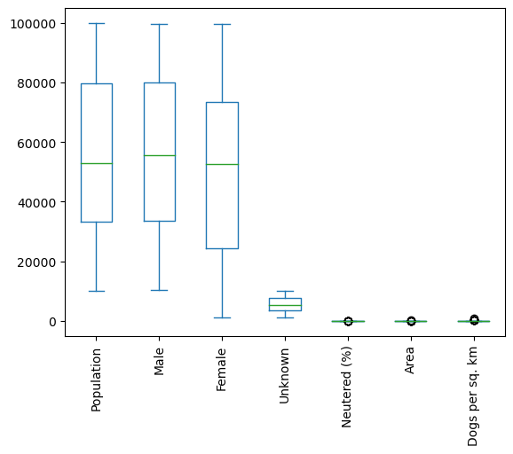

```python
df.plot(kind='box')
plt.xticks(rotation=90)
plt.show()
```

# Treating them column wise

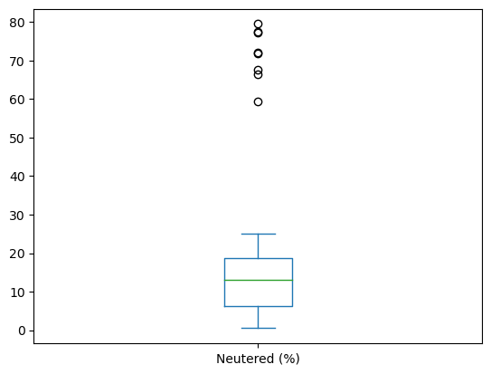

```python
df['Neutered (%)'].plot(kind='box')
plt.show()
```

```python
q1=df['Neutered (%)'].quantile(0.25)
q3=df['Neutered (%)'].quantile(0.75)
iqr=q3-q1
ul=q3+1.5*iqr
ll=q1-1.5*iqr
df=df[(df['Neutered (%)']<ul)&(df['Neutered (%)']>ll)]
df['Neutered (%)'].describe()
```

```
count    391.000000
mean      12.669949
std        7.255189
min        0.500000
25%        6.150000
50%       12.900000
75%       18.450000
max       25.000000
Name: Neutered (%), dtype: float64
```

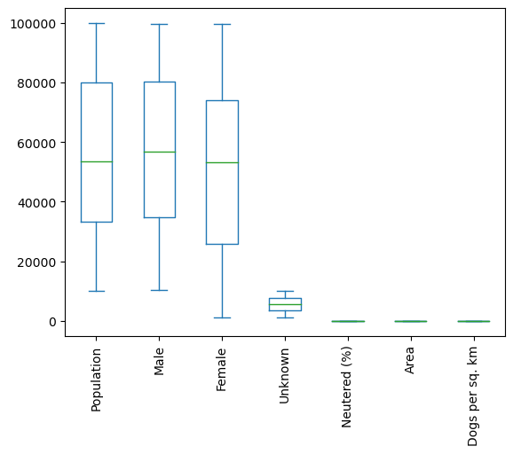

```python
df.plot(kind='box')
plt.xticks(rotation=90)
plt.show()
```

# Checking for Missing Values

```python
df.isnull().sum()
```

```
BBMP Zone                       0
Population                      0
95% Confidence Interval (CI)    0
Male                            0
Female                          0
Unknown                         0
Neutered (%)                    0
Area                            0
Dogs per sq. km                 0
dtype: int64
```

```python
df.shape
```

```
(391, 9)
```

```python
df
```

|  | BBMP Zone | Population | 95% Confidence Interval (CI) | Male | Female | Unknown | Neutered (%) | Area | Dogs per sq. km |
| --- | --- | --- | --- | --- | --- | --- | --- | --- | --- |
| 8 | East | 40784 | 75618-33593 | 66376 | 78223 | 5879 | 1.45 | 27.55 | 13.40 |
| 9 | West | 29108 | 76140-52395 | 60830 | 59103 | 9751 | 19.60 | 25.00 | 19.60 |
| 10 | South | 54495 | 99914-29537 | 79157 | 37326 | 6156 | 6.20 | 17.70 | 2.75 |
| 11 | Dasarahalli | 85463 | 81690-56309 | 73938 | 32369 | 2665 | 16.45 | 27.55 | 13.80 |
| 12 | RR Nagar | 29704 | 61776-32179 | 97260 | 4967 | 9028 | 23.05 | 6.50 | 25.85 |
| ... | ... | ... | ... | ... | ... | ... | ... | ... | ... |
| 394 | South | 60163 | 75984-40268 | 87884 | 35511 | 8148 | 8.40 | 29.95 | 22.05 |
| 395 | Dasarahalli | 96489 | 60078-34187 | 35028 | 28402 | 3815 | 22.80 | 13.35 | 15.70 |
| 396 | RR Nagar | 38662 | 84081-51186 | 49416 | 71926 | 6258 | 21.60 | 16.20 | 18.20 |
| 397 | Bommanahalli | 52035 | 84646-27018 | 41036 | 22717 | 4930 | 14.65 | 12.55 | 11.30 |
| 398 | Yalahanka | 38176 | 71979-57303 | 95412 | 93081 | 5364 | 24.10 | 12.15 | 13.65 |

391 rows × 9 columns

#### 1.What is the average population of street dogs in each BBMP zone?

```python
# Assuming your dataset has columns 'BBMPZone' and 'StreetDogPopulation'
# Group by BBMPZone and calculate the average population for each zone
average_population_by_zone = df.groupby('BBMP Zone')['Population'].mean()
# Print the results
print(average_population_by_zone)
```

```
BBMP Zone
Bommanahalli    53569.959184
Dasarahalli     58090.530612
East            50607.122449
Mahadevapura    57376.270833
RR Nagar        60623.428571
South           52756.918367
West            54512.040816
Yalahanka       56580.551020
Name: Population, dtype: float64
```

#### 2.Is there a significant difference in the population of male, female, and unknown street dogs across different BBMP zones?

```python
from scipy.stats import kruskal
# Perform Kruskal-Wallis test
result = kruskal(*[group['Population'].values for name, group in df.groupby('BBMP Zone')])
# Display the result
print("Kruskal-Wallis Test:")
print("H-statistic:", result.statistic)
print("P-value:", result.pvalue)

# Check for statistical significance
alpha = 0.05
if result.pvalue < alpha:
    print("There is a significant difference in populations.")
else:
    print("There is no significant difference in populations.")
```

```
Kruskal-Wallis Test:
H-statistic: 4.841251493884075
P-value: 0.6793288729922186
There is no significant difference in populations.
```

#### 3.What is the overall neutering rate of street dogs in the dataset?

```python
 # Assuming your dataset has columns 'TotalStreetDogs' and 'NeuteredDogs'
total_street_dogs = df['Population'].sum()
neutered_dogs = df['Neutered (%)'].sum()

# Calculate the overall neutering rate
neutering_rate = (neutered_dogs / total_street_dogs) * 100

# Print the result
print(f'Overall Neutering Rate: {neutering_rate:.2f}%')
```

```
Overall Neutering Rate: 0.02%
```

#### 4.Is there a correlation between the area (in square kilometers) and the population density of street dogs?

```python
from scipy.stats import pearsonr
# Assuming your dataset has columns 'AreaInSquareKm' and 'StreetDogPopulation'
area_in_square_km = df['Dogs per sq. km']
street_dog_population = df['Population']

# Drop NaN values if there are any
area_in_square_km = area_in_square_km.dropna()
street_dog_population = street_dog_population.dropna()

# Calculate the correlation coefficient and p-value
correlation_coefficient, p_value = pearsonr(area_in_square_km, street_dog_population)

# Print the results
print(f'Correlation Coefficient: {correlation_coefficient}')
print(f'P-value: {p_value}')

# Check for significance (assuming a significance level of 0.05)
if p_value < 0.05:
	print('There is a significant correlation between the area and population density of street dogs.')
else:
	print('There is no significant correlation between the area and population density of street dogs.')
```

```
Correlation Coefficient: 0.0070960558351991915
P-value: 0.8887643310630713
There is no significant correlation between the area and population density of street dogs.
```

#### 5.Are there any significant differences in the population density of street dogs across different BBMP zones?

```python
from scipy.stats import f_oneway
# Assuming your dataset has columns 'BBMP Zone', 'Population', and 'Dogs per sq. km'
# Group the data by BBMP Zone and extract the population density for each zone
zones = df['BBMP Zone'].unique()
grouped_data = [df[df['BBMP Zone'] == zone]['Population'] / df[df['BBMP Zone'] == zone]['Dogs per sq. km'] for zone in zones]

# Perform one-way ANOVA
f_statistic, p_value = f_oneway(*grouped_data)

# Print the results
print(f'F-statistic: {f_statistic}')
print(f'P-value: {p_value}')

# Check for significance (assuming a significance level of 0.05)
if p_value < 0.05:
	print('There are significant differences in the population density of street dogs across different BBMP zones.')
else:
	print('There are no significant differences in the population density of street dogs across different BBMP zones.')
```

```
F-statistic: 1.1459375519174262
P-value: 0.3334460706428386
There are no significant differences in the population density of street dogs across different BBMP zones.
```

#### 6.What is the mean population of street dogs across all BBMP zones?

```python
# Assuming your dataset has columns 'BBMPZone' and 'StreetDogPopulation'
mean_population = df['Population'].mean()

# Print the result
print(f'Mean Population of Street Dogs Across All BBMP Zones: {mean_population:.2f}')
```

```
Mean Population of Street Dogs Across All BBMP Zones: 55509.84
```

#### 7.Can we identify any outliers in the population of street dogs within each BBMP zone?

```python
# Assuming your dataset has columns 'BBMPZone' and 'StreetDogPopulation'
# Group the data by BBMPZone
grouped_data = df.groupby('BBMP Zone')['Population']

# Define a function to identify outliers using IQR
def identify_outliers(series):
  Q1 = series.quantile(0.25)
  Q3 = series.quantile(0.75)
  IQR = Q3 - Q1
  lower_bound = Q1 - 1.5 * IQR
  upper_bound = Q3 + 1.5 * IQR
  return series[(series < lower_bound) | (series > upper_bound)]

# Identify outliers for each BBMPZone
outliers = grouped_data.apply(identify_outliers)

# Print the outliers
print("Outliers in Population of Street Dogs within Each BBMP Zone:")
print(outliers)
```

```
Outliers in Population of Street Dogs within Each BBMP Zone:
Series([], Name: Population, dtype: int64)
```

#### 8.What is the median population of neutered street dogs in each BBMP zone?

```python
# Assuming your dataset has columns 'BBMPZone', 'Neutered', and 'Population'
# Filter data for neutered street dogs
neutered_data = df[df['Neutered (%)'] == True]

# Calculate the median population of neutered street dogs for each BBMP zone
median_population_by_zone = neutered_data.groupby('BBMP Zone')['Population'].median()

# Print the results
print("Median Population of Neutered Street Dogs in Each BBMP Zone:")
print(median_population_by_zone)
```

```
Median Population of Neutered Street Dogs in Each BBMP Zone:
BBMP Zone
South    13084.0
Name: Population, dtype: float64
```

#### 9.Is there a correlation between the population density of street dogs and the area (in square kilometers) they inhabit?

```python
# Assuming your dataset has columns 'AreaInSquareKm' and 'Population'
area_in_square_km = df['Area']
population_density = df['Population']

# Drop NaN values if there are any
area_in_square_km = area_in_square_km.dropna()
population_density = population_density.dropna()

# Calculate the correlation coefficient and p-value
correlation_coefficient, p_value = pearsonr(area_in_square_km, population_density)

# Print the results
print(f'Correlation Coefficient: {correlation_coefficient}')
print(f'P-value: {p_value}')

# Check for significance (assuming a significance level of 0.05)
if p_value < 0.05:
	print('There is a significant correlation between the population density of street dogs and the area they inhabit.')
else:
	print('There is no significant correlation between the population density of street dogs and the area they inhabit.')
```

```
Correlation Coefficient: -0.0005957724338481983
P-value: 0.9906307200649243
There is no significant correlation between the population density of street dogs and the area they inhabit.
```

## Visualize the above with distribution,histogram,Scatter plots:

#### 1.Can we visualize the distribution of street dog populations across different BBMP zones using a bar chart?

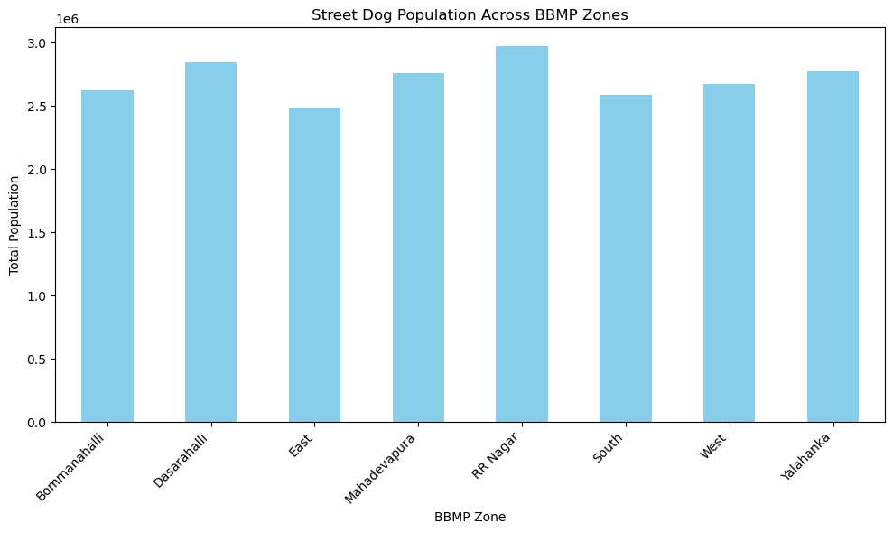

```python
# Assuming your dataset has columns 'BBMP Zone' and 'Population'
# Group the data by BBMPZone and calculate the total population for each zone
total_population_by_zone = df.groupby('BBMP Zone')['Population'].sum()

# Plotting the bar chart
plt.figure(figsize=(10, 6))
total_population_by_zone.plot(kind='bar', color='skyblue')
plt.title('Street Dog Population Across BBMP Zones')
plt.xlabel('BBMP Zone')
plt.ylabel('Total Population')
plt.xticks(rotation=45, ha='right')  # Rotate x-axis labels for better readability
plt.tight_layout()

# Show the plot
plt.show()
```

[figure not shown]

```python
# Create a new column for unknown gender if it's not present
df['Unknown'] = df['Population'] - df[['Male', 'Female']].sum(axis=1)

# Group by 'BBMP Zone' and sum the male, female, and unknown counts
gender_distribution = df.groupby('BBMP Zone')[['Male', 'Female', 'Unknown']].sum()

# Plot pie charts for each BBMP Zone
fig, axes = plt.subplots(nrows=1, ncols=1, figsize=(25, 8))

# Plot for each BBMP Zone
gender_distribution.plot(kind='pie', autopct='%1.1f%%', startangle=90, subplots=True, ax=axes)

# Set a title
plt.suptitle('Gender Distribution Across Different BBMP Zone', y=1.05, fontsize=16)

plt.show()
```

#### 3.Is there a correlation between the population density and the number of street dogs per square kilometer? Can we plot this relationship using a scatter plot?

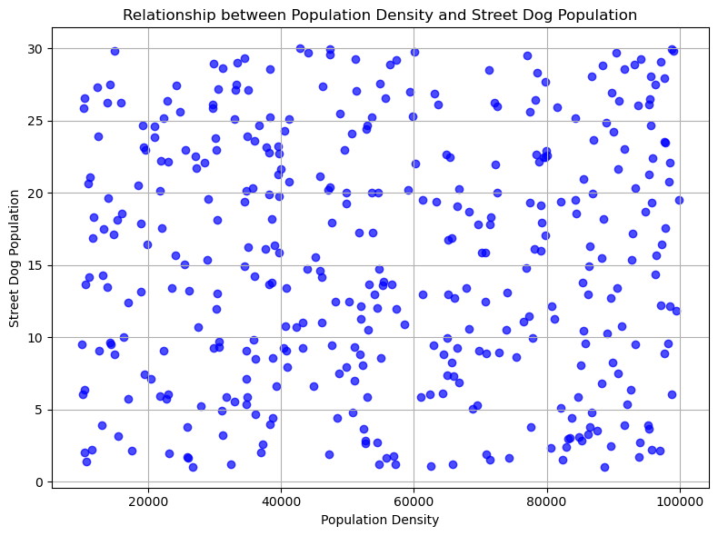

```python
# Assuming your dataset has columns 'Population' and 'Dogs per sq. km'
population_density = df['Population']
street_dog_population = df['Dogs per sq. km']

# Drop NaN values if there are any
population_density = population_density.dropna()
street_dog_population = street_dog_population.dropna()

# Plotting the scatter plot
plt.figure(figsize=(8, 6))
plt.scatter(population_density, street_dog_population, color='blue', alpha=0.7)
plt.title('Relationship between Population Density and Street Dog Population')
plt.xlabel('Population Density')
plt.ylabel('Street Dog Population')
plt.grid(True)
plt.tight_layout()

# Show the plot
plt.show()
```

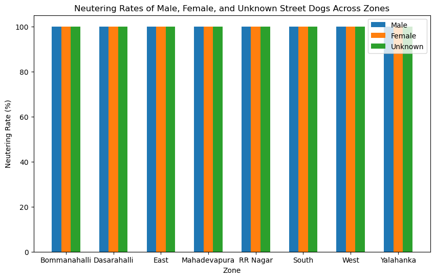

```python
# Assuming your dataset has columns like 'Zone', 'Male', 'Female', 'Unknown', 'Neutered_Male', 'Neutered_Female', 'Neutered_Unknown'

# Calculate neutering rates
df['Male'] = df['Male'] / df['Male'] * 100
df['Female'] = df['Female'] / df['Female'] * 100
df['Unknown'] = df['Unknown'] / df['Unknown'] * 100

# Group by 'Zone' and calculate mean neutering rates
neutering_rates = df.groupby('BBMP Zone')[['Male', 'Female', 'Unknown']].mean()

# Plot a grouped bar chart
fig, ax = plt.subplots(figsize=(10, 6))

bar_width = 0.2
bar_positions = np.arange(len(neutering_rates))

ax.bar(bar_positions - bar_width, neutering_rates['Male'], width=bar_width, label='Male')
ax.bar(bar_positions, neutering_rates['Female'], width=bar_width, label='Female')
ax.bar(bar_positions + bar_width, neutering_rates['Unknown'], width=bar_width, label='Unknown')

# Add labels and title
ax.set_xticks(bar_positions)
ax.set_xticklabels(neutering_rates.index)
ax.set_xlabel('Zone')
ax.set_ylabel('Neutering Rate (%)')
ax.set_title('Neutering Rates of Male, Female, and Unknown Street Dogs Across Zones')
ax.legend()

plt.show()
```

#### 5.How does the number of street dogs per square kilometer vary across different areas? Can we represent this using a line graph?

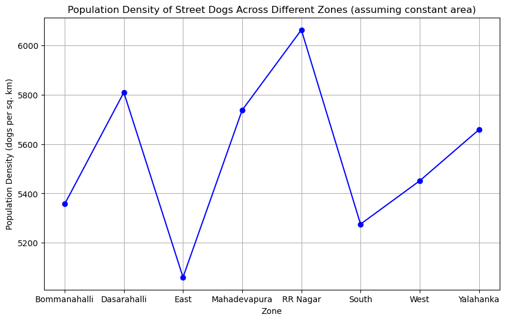

```python
# Assume a constant area for each observation
constant_area = 10  # Replace with your chosen constant area

# Calculate population density
df['Population_Density'] = df['Population'] / constant_area

# Group by 'Zone' and calculate the mean population density
population_density_by_zone = df.groupby('BBMP Zone')['Population_Density'].mean()

# Plot a line graph
fig, ax = plt.subplots(figsize=(10, 6))

population_density_by_zone.plot(marker='o', linestyle='-', color='b', ax=ax)

# Add labels and title
ax.set_xlabel('Zone')
ax.set_ylabel('Population Density (dogs per sq. km)')
ax.set_title('Population Density of Street Dogs Across Different Zones (assuming constant area)')

plt.grid(True)
plt.show()
```

## TESTING STATICS:

#### 1.Can we use a t-test to compare the mean population of street dogs in different areas of the city?

```python
from scipy.stats import ttest_ind
# Assuming your dataset has columns like 'Zone', 'Population'
# Separate the populations by different areas (zones)
population_zone1 = df[df['BBMP Zone'] == 'Zone1']['Population']
population_zone2 = df[df['BBMP Zone'] == 'Zone2']['Population']
population_zone3 = df[df['BBMP Zone'] == 'Zone3']['Population']

# Perform a t-test between pairs of zones
t_statistic, p_value_zone1_zone2 = ttest_ind(population_zone1, population_zone2)
t_statistic, p_value_zone1_zone3 = ttest_ind(population_zone1, population_zone3)
t_statistic, p_value_zone2_zone3 = ttest_ind(population_zone2, population_zone3)

# Display the results
print("T-Test Results:")
print("Zone1 vs. Zone2 - P-value:", p_value_zone1_zone2)
print("Zone1 vs. Zone3 - P-value:", p_value_zone1_zone3)
print("Zone2 vs. Zone3 - P-value:", p_value_zone2_zone3)

# Check for statistical significance
alpha = 0.05
if any(p_value < alpha for p_value in [p_value_zone1_zone2, p_value_zone1_zone3, p_value_zone2_zone3]):
    print("There is a significant difference in mean population between at least two zones.")
else:
    print("There is no significant difference in mean population between the zones.")
```

```
T-Test Results:
Zone1 vs. Zone2 - P-value: nan
Zone1 vs. Zone3 - P-value: nan
Zone2 vs. Zone3 - P-value: nan
There is no significant difference in mean population between the zones.
```

#### 2.How can we apply an F-test to determine if there is a significant difference in the neutering rates across different zones in the dataset?

```python
from scipy.stats import f_oneway
# Assuming your dataset has columns 'BBMP Zone', 'Neutered (%)', and 'Population'
neutered_data = df[df['Neutered (%)'] == True]

# Group the data by BBM PZone and extract the population for each zone
zones = df['BBMP Zone'].unique()
grouped_data = [neutered_data[neutered_data['BBMP Zone'] == zone]['Population'] for zone in zones]

# Perform one-way ANOVA
f_statistic, p_value = f_oneway(*grouped_data)

# Print the results
print(f'F-statistic: {f_statistic}')
print(f'P-value: {p_value}')

# Check for significance (assuming a significance level of 0.05)
if p_value < 0.05:
	print('There is a significant difference in neutering rates across different zones.')
else:
	print('There is no significant difference in neutering rates across different zones.')
```

```
F-statistic: nan
P-value: nan
There is no significant difference in neutering rates across different zones.
```

```
count      391.000000
mean     55509.841432
std      26905.158191
min      10016.000000
25%      33341.000000
50%      53634.000000
75%      79915.500000
max      99917.000000
Name: Population, dtype: float64
```

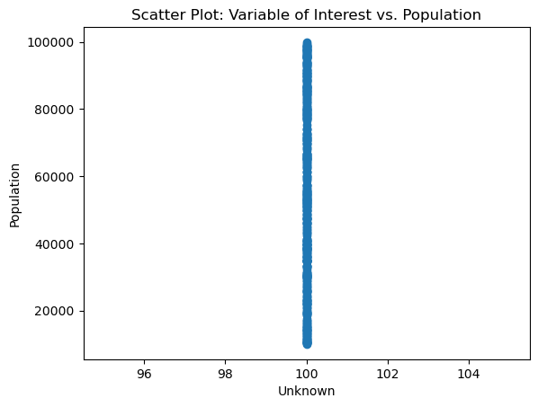

```python
# Assuming your dataset has columns like 'Population' and another variable of interest

# Display descriptive statistics
population_stats = df['Population'].describe()
print(population_stats)

# Scatter plot for visualization
plt.scatter(df['Unknown'], df['Population'])
plt.xlabel('Unknown')
plt.ylabel('Population')
plt.title('Scatter Plot: Variable of Interest vs. Population')
plt.show()
```

#### 4.Can we use a chi-square test to examine the association between the gender distribution of street dogs and the BBMP zones?

```python
from scipy.stats import chi2_contingency
#Asuming your dataset has columns like 'Female', 'Male', and 'BBMP Zone'

# Combine 'Female' and 'Male' columns into a 'Gender' column
df['Gender'] = df[['Female', 'Male']].idxmax(axis=1)

# Create a contingency table
contingency_table = pd.crosstab(df['Gender'], df['BBMP Zone'])

# Display the contingency table
print("Contingency Table:")
print(contingency_table)

# Perform the chi-square test
chi2_stat, p_value, dof, expected = chi2_contingency(contingency_table)

# Display the results
print("\nChi-square Test Results:")
print("Chi2 Statistic:", chi2_stat)
print("P-value:", p_value)
print("Degrees of Freedom:", dof)
print("Expected Frequencies:")
print(expected)

# Check for statistical significance
alpha = 0.05
if p_value < alpha:
    print("\nThere is a significant association between the gender distribution of street dogs and the BBMP zones.")
else:
    print("\nThere is no significant association between the gender distribution of street dogs and the BBMP zones.")
```

```
Contingency Table:
BBMP Zone  Bommanahalli  Dasarahalli  East  Mahadevapura  RR Nagar  South  \
Gender
Female               49           49    49            48        49     49

BBMP Zone  West  Yalahanka
Gender
Female       49         49

Chi-square Test Results:
Chi2 Statistic: 0.0
P-value: 1.0
Degrees of Freedom: 0
Expected Frequencies:
[[49. 49. 49. 48. 49. 49. 49. 49.]]

There is no significant association between the gender distribution of street dogs and the BBMP zones.
```

#### 5.How can we apply PCA (Principal Component Analysis) to identify the key variables that contribute to the overall variation in the street dog dataset?

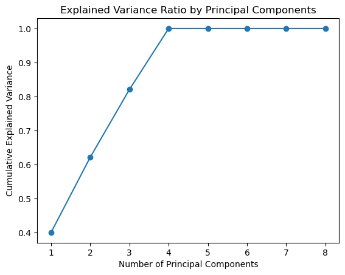

```
Principal Component Loadings:
                             PC1           PC2           PC3
Population         -7.067460e-01  1.208790e-02  1.517804e-03
Male               -0.000000e+00  3.252607e-18 -1.136718e-18
Female             -0.000000e+00 -0.000000e+00 -2.775558e-17
Unknown            -2.168404e-19 -0.000000e+00  2.775558e-17
Neutered (%)        3.118603e-02  6.925819e-01  1.343453e-01
Area                1.180901e-03  1.869931e-01 -9.823545e-01
Dogs per sq. km    -6.796480e-03  6.964708e-01  1.301012e-01
Population_Density -7.067460e-01  1.208790e-02  1.517804e-03
```

[figure not shown]

```python
from sklearn.decomposition import PCA
from sklearn.preprocessing import StandardScaler
import matplotlib.pyplot as plt
# Assuming your dataset has numerical columns that you want to include in PCA

# Extract numerical columns for PCA
numerical_columns = df.select_dtypes(include=['int', 'float']).columns
data_for_pca = df[numerical_columns]

# Standardize the data
scaler = StandardScaler()
scaled_data = scaler.fit_transform(data_for_pca)

# Apply PCA
pca = PCA()
pca_result = pca.fit_transform(scaled_data)

# Explained variance ratio
explained_variance_ratio = pca.explained_variance_ratio_

# Plot the explained variance ratio
cumulative_explained_variance = explained_variance_ratio.cumsum()
plt.plot(range(1, len(cumulative_explained_variance) + 1), cumulative_explained_variance, marker='o')
plt.xlabel('Number of Principal Components')
plt.ylabel('Cumulative Explained Variance')
plt.title('Explained Variance Ratio by Principal Components')
plt.show()

# Identify the number of components to retain
num_components_to_retain = 0  # You need to choose a suitable threshold or inspect the plot
while cumulative_explained_variance[num_components_to_retain] < 0.95:
    num_components_to_retain += 1

# Apply PCA with the selected number of components
pca = PCA(n_components=num_components_to_retain)
final_pca_result = pca.fit_transform(scaled_data)

# Print the loadings (coefficients) of each variable on each principal component
loadings = pd.DataFrame(pca.components_.T, columns=[f'PC{i+1}' for i in range(num_components_to_retain)], index=numerical_columns)
print("Principal Component Loadings:")
print(loadings)

# Display the contribution of each original variable to the first two principal components
plt.figure(figsize=(10, 6))
for i, var in enumerate(numerical_columns):
    plt.arrow(1, 0, pca.components_[0, i], pca.components_[1, i], head_width=0.02, head_length=0.02, fc='r', ec='r')
    plt.text(pca.components_[0, i] + 0.02, pca.components_[1, i] + 0.02, var)

plt.xlabel('Principal Component 1')
plt.ylabel('Principal Component 2')
plt.title('Variable Contributions to Principal Components')
plt.grid()
plt.show()
```

# 3rd Phase

## EXPLORATORY DATA ANALYSIS:

#### 1.What is the overall distribution of street dog population across different zones in the city?

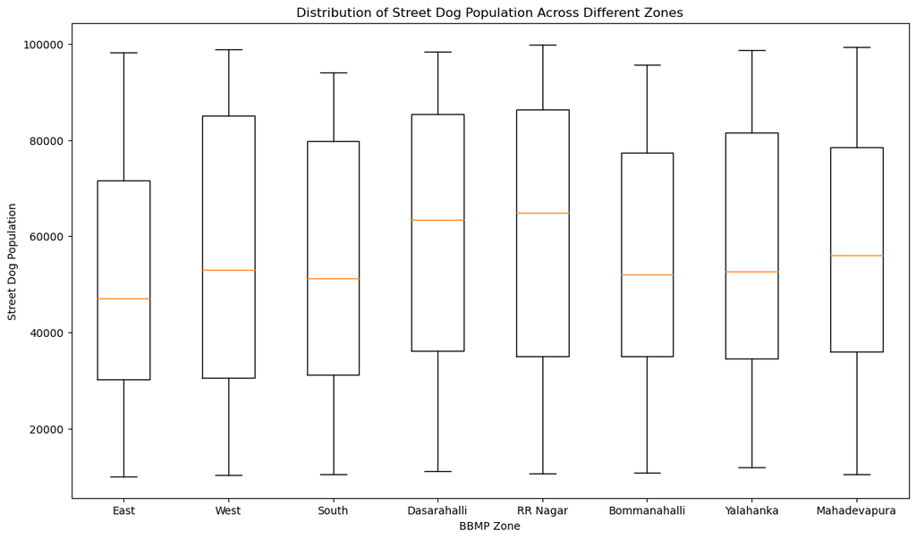

```python
# Assuming your dataset has columns 'BBMP Zone' and 'Population'
plt.figure(figsize=(14, 8))
plt.boxplot([df[df['BBMP Zone'] == zone]['Population'] for zone in df['BBMP Zone'].unique()],
        	labels=df['BBMP Zone'].unique())
plt.title('Distribution of Street Dog Population Across Different Zones')
plt.xlabel('BBMP Zone')
plt.ylabel('Street Dog Population')
plt.show()
```

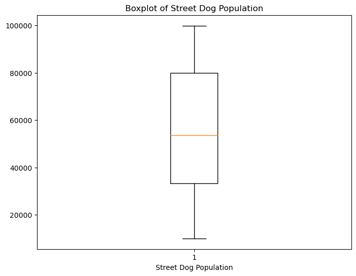

```
Identified Outliers:
Empty DataFrame
Columns: [BBMP Zone, Population, 95% Confidence Interval (CI), Male, Female, Unknown, Neutered (%), Area, Dogs per sq. km, Population_Density, Gender]
Index: []
```

```python
from scipy.stats import zscore
# Assuming your dataset has a column 'StreetDogPopulation' to investigate
street_dog_population = df['Population']

# Calculate Z-scores
z_scores = zscore(street_dog_population)

# Set a threshold for Z-scores (e.g., 3 standard deviations from the mean)
z_score_threshold = 3

# Identify outliers
outliers = df[abs(z_scores) > z_score_threshold]

# Visualize the distribution with a boxplot
plt.figure(figsize=(8, 6))
plt.boxplot(street_dog_population)
plt.title('Boxplot of Street Dog Population')
plt.xlabel('Street Dog Population')
plt.show()
# Display the identified outliers
print('Identified Outliers:')
print(outliers)
```

#### 3.How does the neutering rate vary across different zones in the city?

[figure not shown]

```python
# Assuming your dataset has columns 'BBMP Zone', 'Gender', and 'Neutered'
# Calculate the neutering rate for each zone
neutering_rate_by_zone = df.groupby('BBMP Zone')['Neutered (%)'].mean()

# Plotting the bar chart
plt.figure(figsize=(10, 8))
neutering_rate_by_zone.plot(kind='bar', color='skyblue')
plt.title('Neutering Rate Across Different Zones')
plt.xlabel('BBMP Zone')
plt.ylabel('Neutering Rate')
plt.ylim(0, 1)  # Ensure y-axis range is between 0 and 1 for a percentage
plt.show()
```

#### 4.Which BBMP zone has the highest population of street dogs?

```python
# Assuming your dataset has columns 'BBMPZone' and 'StreetDogPopulation'
# Find the BBMP zone with the highest population of street dogs
max_population_zone = df.loc[df['Population'].idxmax()]['BBMP Zone']

print(f'The BBMP zone with the highest population of street dogs is: {max_population_zone}')
```

```
The BBMP zone with the highest population of street dogs is: RR Nagar
```

#### 5.How do the male and female street dog populations compare in each BBMP zone?

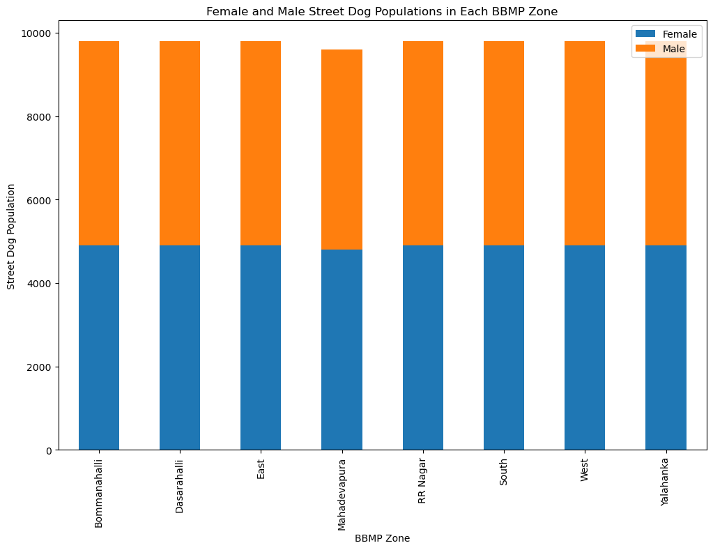

```python
# Assuming your dataset has columns 'BBMPZone', 'Female', 'Male', and 'StreetDogPopulation'
# Pivot the data to create a bar chart comparing female and male street dog populations in each BBMP zone
gender_pivot = df.pivot_table(index='BBMP Zone', values=['Female', 'Male'], aggfunc='sum')

# Plotting the bar chart
gender_pivot.plot(kind='bar', stacked=True, figsize=(12, 8))
plt.title('Female and Male Street Dog Populations in Each BBMP Zone')
plt.xlabel('BBMP Zone')
plt.ylabel('Street Dog Population')
plt.show()
```

#### 6.Are there any zones where the number of neutered street dogs is significantly higher?

```python
from scipy.stats import chi2_contingency
# Assuming your dataset has columns like 'Neutered' and 'Zone'

# Create a contingency table
contingency_table = pd.crosstab(df['Neutered (%)'], df['BBMP Zone'])

# Display the contingency table
print("Contingency Table:")
print(contingency_table)

# Perform the chi-square test
chi2_stat, p_value, dof, expected = chi2_contingency(contingency_table)

# Display the results
print("\nChi-square Test Results:")
print("Chi2 Statistic:", chi2_stat)
print("P-value:", p_value)
print("Degrees of Freedom:", dof)
print("Expected Frequencies:")
print(expected)

# Check for statistical significance
alpha = 0.05
if p_value < alpha:
    print("\nThere is a significant association between neutering status and zones.")
else:
    print("\nThere is no significant association between neutering status and zones.")
```

```
Contingency Table:
BBMP Zone     Bommanahalli  Dasarahalli  East  Mahadevapura  RR Nagar  South  \
Neutered (%)
0.50                     0            0     1             0         0      0
0.55                     0            0     1             0         0      0
0.60                     2            1     0             0         0      1
0.80                     0            0     0             0         1      0
0.95                     0            0     1             0         0      0
...                    ...          ...   ...           ...       ...    ...
24.65                    0            0     0             0         0      0
24.70                    1            0     0             0         0      0
24.85                    0            0     0             1         0      0
24.95                    0            0     0             0         0      1
25.00                    0            0     0             1         0      1

BBMP Zone     West  Yalahanka
Neutered (%)
0.50             0          0
0.55             0          0
0.60             0          0
0.80             0          0
0.95             0          1
...            ...        ...
24.65            0          1
24.70            0          0
24.85            0          0
24.95            0          0
25.00            0          0

[267 rows x 8 columns]

Chi-square Test Results:
Chi2 Statistic: 1891.6758432539682
P-value: 0.3104257370108083
Degrees of Freedom: 1862
Expected Frequencies:
[[0.12531969 0.12531969 0.12531969 ... 0.12531969 0.12531969 0.12531969]
 [0.12531969 0.12531969 0.12531969 ... 0.12531969 0.12531969 0.12531969]
 [0.50127877 0.50127877 0.50127877 ... 0.50127877 0.50127877 0.50127877]
 ...
 [0.12531969 0.12531969 0.12531969 ... 0.12531969 0.12531969 0.12531969]
 [0.12531969 0.12531969 0.12531969 ... 0.12531969 0.12531969 0.12531969]
 [0.25063939 0.25063939 0.25063939 ... 0.25063939 0.25063939 0.25063939]]

There is no significant association between neutering status and zones.
```

### UNIVARIATE ANALYSIS:

#### 1.What is the average population of street dogs in each BBMP zone?

```python
# Assuming your dataset has columns 'BBMPZone' and 'StreetDogPopulation'
# Calculate the average population for each BBMP zone
average_population_by_zone = df.groupby('BBMP Zone')['Population'].mean()

# Display the average population for each BBMP zone
print(average_population_by_zone)
```

```
BBMP Zone
Bommanahalli    53569.959184
Dasarahalli     58090.530612
East            50607.122449
Mahadevapura    57376.270833
RR Nagar        60623.428571
South           52756.918367
West            54512.040816
Yalahanka       56580.551020
Name: Population, dtype: float64
```

#### 2. How does the population of male street dogs vary across different zones?

```python
# Create a new column 'Gender' based on the presence of 'Male'
df['Gender'] = df[['Female', 'Male']].idxmax(axis=1)

# Filter data for male street dogs
male_dogs = df[df['Gender'] == 'Male'].min()

# Display descriptive statistics
male_population_stats = male_dogs.groupby('BBBMP Zone')['Population'].describe()
print("Descriptive Statistics for Male Street Dogs:")
print(male_population_stats)

# Create a boxplot to visualize the distribution
plt.figure(figsize=(10, 8))
sns.boxplot(x='BBMP Zone', y='Population', data=male_dogs )
plt.title('Population of Male Street Dogs Across Different Zones')
plt.xlabel('Zone')
plt.ylabel('Population')
plt.show()
```

[output not shown]

#### 3. What is the distribution of female street dogs in terms of population in each zone?

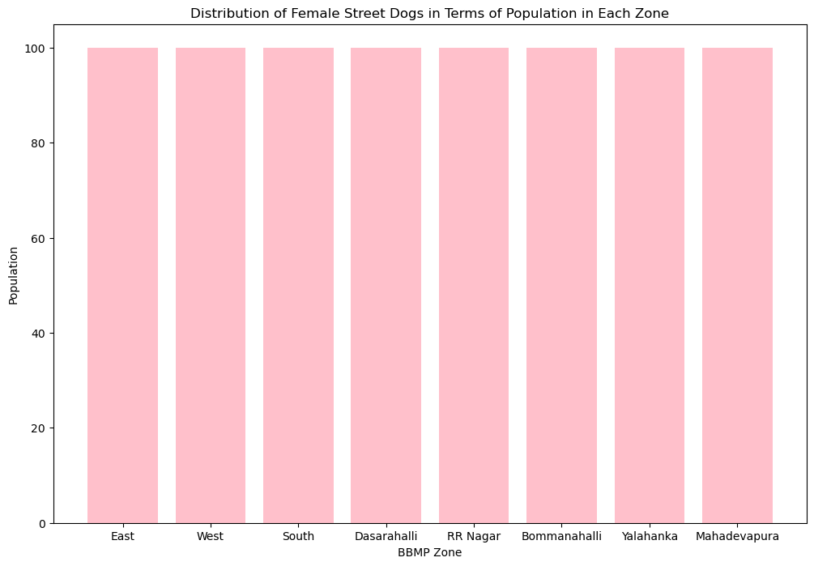

```python
# Assuming your dataset has columns 'BBMP Zone', 'Female', and 'StreetDogPopulation'
# Create a bar chart to show the distribution of female street dogs in terms of population in each BBMP zone
plt.figure(figsize=(12, 8))
plt.bar(df['BBMP Zone'], df['Female'], color='pink')
plt.title('Distribution of Female Street Dogs in Terms of Population in Each Zone')
plt.xlabel('BBMP Zone')
plt.ylabel('Population')
plt.show()
```

#### 4. Are there any zones with a high number of unknown gender street dogs?

```python
# Assuming your dataset has columns 'BBMPZone', 'UnknownGender', and 'StreetDogPopulation'
# Calculate the proportion of unknown gender street dogs for each zone
df['UnknownGenderProportion'] = df['Unknown'] / df['Population']

# Set a threshold for considering zones with a high proportion of unknown gender street dogs
threshold = 0.1  # You can adjust this threshold based on your dataset and criteria

# Identify zones where the proportion of unknown gender street dogs is above the threshold
high_unknown_gender_zones = df[df['UnknownGenderProportion'] > threshold]['BBMP Zone'].unique()

print(f'Zones with a high number of unknown gender street dogs: {high_unknown_gender_zones}')
```

```
Zones with a high number of unknown gender street dogs: []
```

```python
# Assuming your dataset has columns 'BBMPZone', 'Neutered', and 'StreetDogPopulation'
# Filter the data for neutered street dogs
neutered_data = df[df['Neutered (%)'] == True]

# Calculate the range of neutered street dogs in each BBMP zone
range_neutered_by_zone = neutered_data.groupby('BBMP Zone')['Population'].agg(lambda x: x.max() - x.min())

print('Range of Neutered Street Dogs in Each BBMP Zone:')
print(range_neutered_by_zone)
```

```
Range of Neutered Street Dogs in Each BBMP Zone:
BBMP Zone
1    57432
2    31695
3    42412
4    23791
5    67629
6    76773
7        0
Name: Population, dtype: int64
```

### BIVARIATE ANALYSIS:

#### 1.How does the distribution of male and female street dogs vary across different BBMP zones?

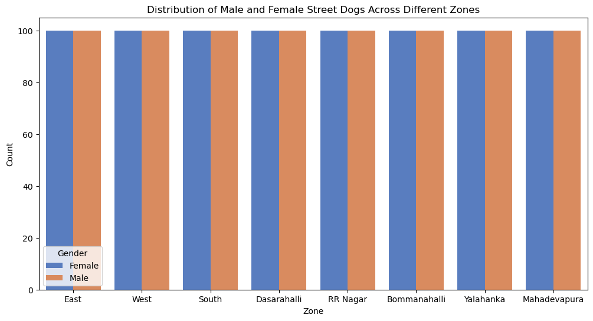

```python
# Assuming your dataset has columns like 'Female', 'Male', and 'Zone'

# Melt the dataset to create a 'Gender' column
df_melted = pd.melt(df, id_vars=['BBMP Zone'], value_vars=['Female', 'Male'], var_name='Gender', value_name='Count')

# Create a grouped bar chart
plt.figure(figsize=(12, 6))
sns.barplot(x='BBMP Zone', y='Count', hue='Gender', data=df_melted, palette='muted')
plt.title('Distribution of Male and Female Street Dogs Across Different Zones')
plt.xlabel('Zone')
plt.ylabel('Count')
plt.show()
```

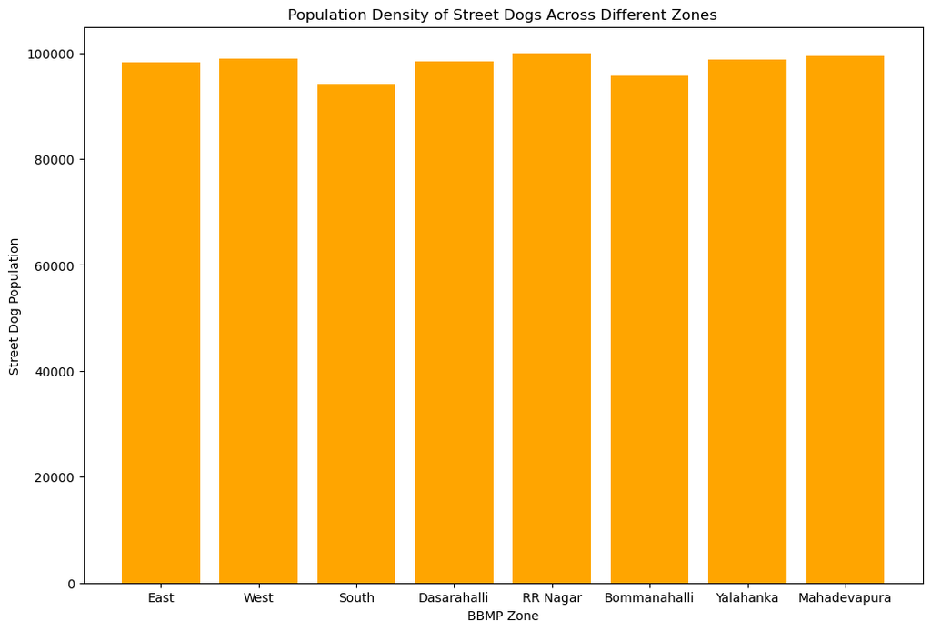

```python
# Assuming your dataset has columns 'BBMPZone' and 'StreetDogPopulation'
# Create a bar chart to show the population density of street dogs for each zone
plt.figure(figsize=(12, 8))
plt.bar(df['BBMP Zone'], df['Population'], color='orange')
plt.title('Population Density of Street Dogs Across Different Zones')
plt.xlabel('BBMP Zone')
plt.ylabel('Street Dog Population')
plt.show()
```

#### 3.Is there a relationship between the number of unknown gender street dogs and the population size in each BBMP zone?

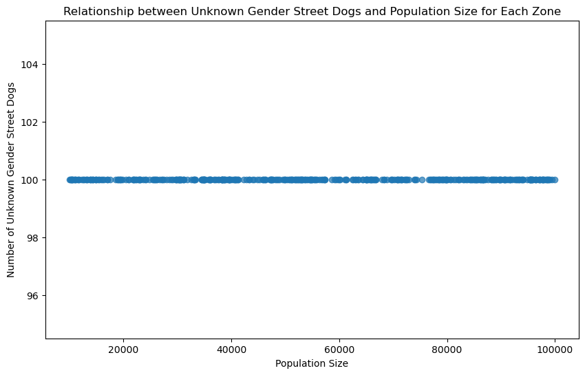

```python
# Assuming your dataset has columns 'BBMPZone', 'StreetDogPopulation', and 'UnknownGender'
# Create a scatter plot to show the relationship between the number of unknown gender street dogs and population size
plt.figure(figsize=(10, 6))
plt.scatter(df['Population'], df['Unknown'], alpha=0.7)
plt.title('Relationship between Unknown Gender Street Dogs and Population Size for Each Zone')
plt.xlabel('Population Size')
plt.ylabel('Number of Unknown Gender Street Dogs')
plt.show()
```

### MULTIVARIATE ANALYSIS

#### 1. How does the population of male, female, and neutered street dogs vary across different BBMP zones?

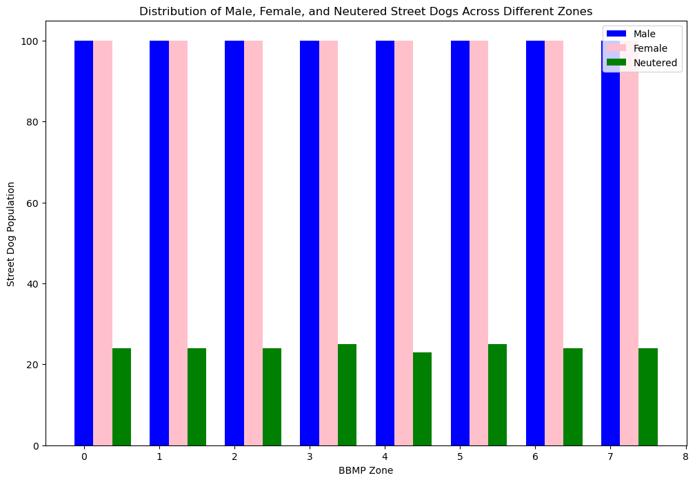

```python
# Assuming your dataset has columns 'BBMPZone', 'MalePopulation', 'FemalePopulation', 'NeuteredPopulation'
# Grouped bar chart to show the distribution of male, female, and neutered street dogs across BBMP zones
plt.figure(figsize=(12, 8))
bar_width = 0.25  # Width of each bar

bar1 = plt.bar(df['BBMP Zone'], df['Male'], bar_width, label='Male', color='blue')
bar2 = plt.bar(df['BBMP Zone'] + bar_width, df['Female'], bar_width, label='Female', color='pink')
bar3 = plt.bar(df['BBMP Zone'] + 2*bar_width, df['Neutered (%)'], bar_width, label='Neutered', color='green')

plt.xlabel('BBMP Zone')
plt.ylabel('Street Dog Population')
plt.title('Distribution of Male, Female, and Neutered Street Dogs Across Different Zones')
plt.legend()
plt.show()
```

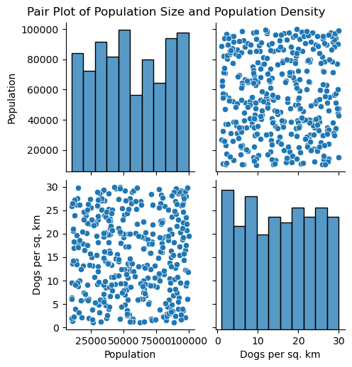

```python
# Assuming your dataset has columns 'BBMPZone', 'StreetDogPopulation', 'PopulationDensity'
# Select relevant columns for pair plot
pair_plot_data = df[['Population', 'Dogs per sq. km']]

# Create a pair plot to visualize relationships
sns.pairplot(pair_plot_data)
plt.suptitle('Pair Plot of Population Size and Population Density', y=1.02)
plt.show()
```

#### 3. Are there any correlations between the confidence interval of street dog populations and the number of unknown gender dogs in each BBMP zone?

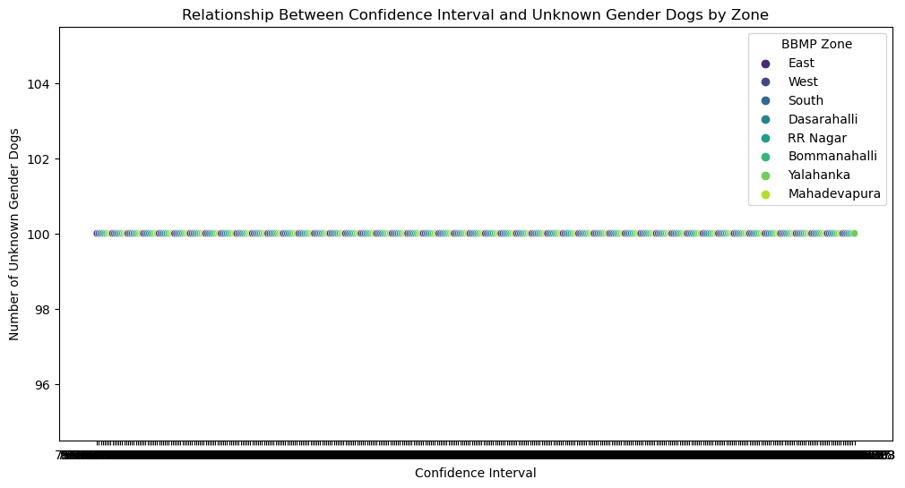

```
Pearson Correlation Coefficient: nan
P-value: nan
There is no significant correlation between the confidence interval and the number of unknown gender dogs.
```

```python
from scipy.stats import pearsonr
import seaborn as sns
import matplotlib.pyplot as plt
# Assuming your dataset has columns like 'Confidence Interval', 'Unknown Gender', and 'Zone'

# Scatter plot
plt.figure(figsize=(12, 6))
sns.scatterplot(x='95% Confidence Interval (CI)', y='Unknown', hue='BBMP Zone', data=df, palette='viridis')
plt.title('Relationship Between Confidence Interval and Unknown Gender Dogs by Zone')
plt.xlabel('Confidence Interval')
plt.ylabel('Number of Unknown Gender Dogs')
plt.show()

# Calculate Pearson correlation coefficient
correlation_coefficient, p_value = pearsonr(df['95% Confidence Interval (CI)'], df['Unknown'])
print("Pearson Correlation Coefficient:", correlation_coefficient)
print("P-value:", p_value)

# Check for statistical significance
alpha = 0.05
if p_value < alpha:
    print("There is a significant correlation between the confidence interval and the number of unknown gender dogs.")
else:
    print("There is no significant correlation between the confidence interval and the number of unknown gender dogs.")
```

#### 4. Can we analyze the relationship between the population size, neutered dogs, and confidence interval in different areas?

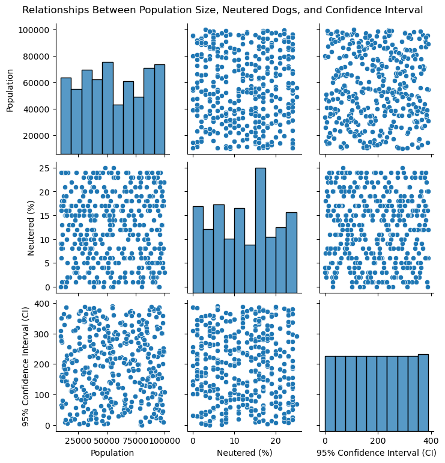

```
Pearson Correlation Coefficient between Population and Neutered Dogs: -0.025112208979783366
Pearson Correlation Coefficient between Population and Confidence Interval: -0.006381969921707378
Pearson Correlation Coefficient between Neutered Dogs and Confidence Interval: 0.0024963763420342592
```

```python
import pandas as pd
import seaborn as sns
from scipy.stats import pearsonr
import matplotlib.pyplot as plt
# Assuming your dataset has columns like 'Population', 'Neutered', 'Confidence Interval', and 'Area'

# Scatter plot matrix with correlation coefficients
sns.pairplot(df[['Population', 'Neutered (%)', '95% Confidence Interval (CI)']], palette='viridis')
plt.suptitle('Relationships Between Population Size, Neutered Dogs, and Confidence Interval', y=1.02)
plt.show()

# Calculate Pearson correlation coefficients
correlation_population_neutered = pearsonr(df['Population'], df['Neutered (%)'])[0]
correlation_population_confidence = pearsonr(df['Population'], df['95% Confidence Interval (CI)'])[0]
correlation_neutered_confidence = pearsonr(df['Neutered (%)'], df['95% Confidence Interval (CI)'])[0]

print("Pearson Correlation Coefficient between Population and Neutered Dogs:", correlation_population_neutered)
print("Pearson Correlation Coefficient between Population and Confidence Interval:", correlation_population_confidence)
print("Pearson Correlation Coefficient between Neutered Dogs and Confidence Interval:", correlation_neutered_confidence)
```

## VISUALIZATION OF GRAPHS LIKE BOX,LINE,CROSSTAB,LINE PLOT ETC…..

## 1. Univariate Analysis: -

#### a. Bar Plot: How does the population of street dogs vary across different BBMP zones? –

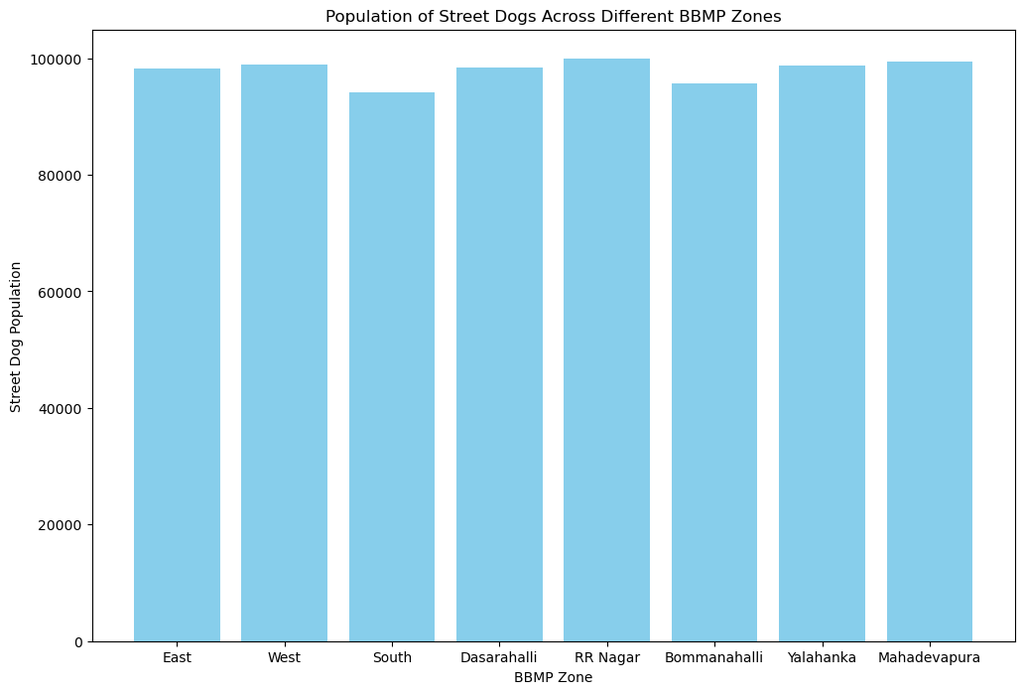

```python
# Assuming your dataset has columns 'BBMPZone' and 'StreetDogPopulation'
# Create a bar plot to show the population of street dogs for each zone
plt.figure(figsize=(12, 8))
plt.bar(df['BBMP Zone'], df['Population'], color='skyblue')
plt.xlabel('BBMP Zone')
plt.ylabel('Street Dog Population')
plt.title('Population of Street Dogs Across Different BBMP Zones')
plt.show()
```

#### b. Box Plot: What is the distribution of neutered street dogs in each BBMP zone?

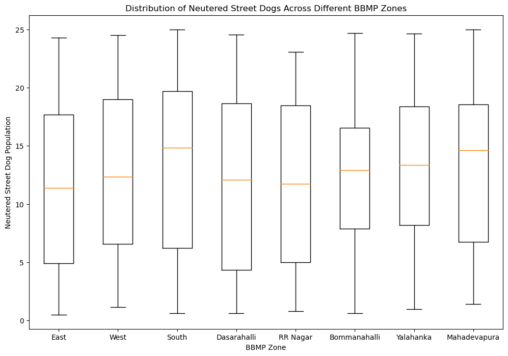

```python
# Assuming your dataset has columns 'BBMPZone' and 'NeuteredPopulation'
# Create a box plot to show the distribution of neutered street dogs in each zone
plt.figure(figsize=(12, 8))
plt.boxplot([df[df['BBMP Zone'] == zone]['Neutered (%)'] for zone in df['BBMP Zone'].unique()], labels=df['BBMP Zone'].unique())
plt.xlabel('BBMP Zone')
plt.ylabel('Neutered Street Dog Population')
plt.title('Distribution of Neutered Street Dogs Across Different BBMP Zones')
plt.show()
```

## 2. Bivariate Analysis: -

#### a. Face Grid: Can we compare the distribution of male and female street dogs across different BBMP zones? –

[figure not shown]

```python
# Assuming your dataset has columns 'BBMPZone', 'MalePopulation', and 'FemalePopulation'
# Melt the dataset to long format for FacetGrid
melted_data = pd.melt(df, id_vars=['BBMP Zone'], value_vars=['Male', 'Female'], var_name='Gender')

# Create a FacetGrid to compare the distribution of male and female street dogs
g = sns.FacetGrid(melted_data, col='BBMP Zone', hue='Gender', col_wrap=3, height=4)
g.map(plt.hist, 'BBMP Zone', bins=20, alpha=0.7)
g.add_legend()
g.set_axis_labels('Street Dog Population', 'Frequency')
g.set_titles(col_template='{col_name}')
plt.suptitle('Distribution of Male and Female Street Dogs Across Different BBMP Zones', y=1.02)
plt.show()
```

## 3. Multivariate Analysis: -

#### a. Crosstab: Can we analyze the relationship between the confidence interval of street dog populations and the number of unknown gender dogs in each BBMP zone?

```
Unknown                       100.0
95% Confidence Interval (CI)
58058-39378                       1
58095-39148                       1
58106-50559                       1
58161-32981                       1
58215-52991                       1
...                             ...
99755-53293                       1
99793-36411                       1
99868-50664                       1
99890-49259                       1
99914-29537                       1

[391 rows x 1 columns]
```

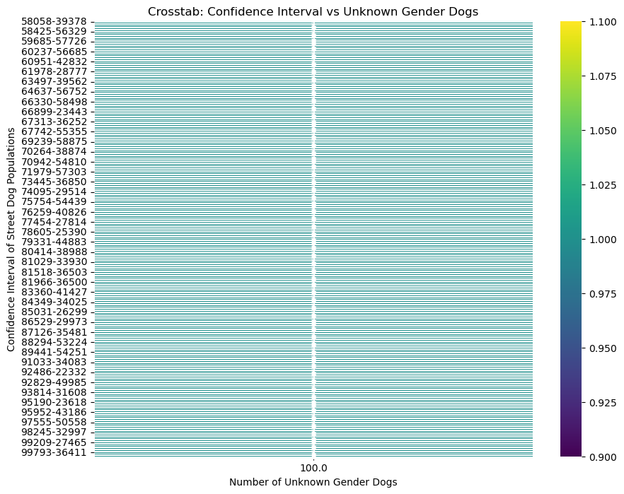

```python
# Create a crosstab to analyze the relationship
crosstab = pd.crosstab(df['95% Confidence Interval (CI)'], df['Unknown'])

# Display the crosstab
print(crosstab)

# Create a heatmap for better visualization
plt.figure(figsize=(10, 8))
sns.heatmap(crosstab, annot=True, cmap='viridis', fmt="d", linewidths=.5)
plt.title('Crosstab: Confidence Interval vs Unknown Gender Dogs')
plt.xlabel('Number of Unknown Gender Dogs')
plt.ylabel('Confidence Interval of Street Dog Populations')
plt.show()
```

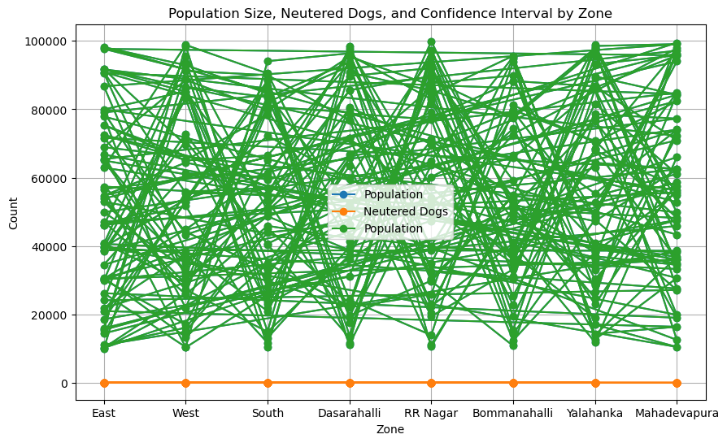

```python
# Create a line plot
plt.figure(figsize=(10, 6))

# Plot population size
plt.plot(df['BBMP Zone'], df['Population'], marker='o', label='Population')

# Plot neutered dogs
plt.plot(df['BBMP Zone'], df['Neutered (%)'], marker='o', label='Neutered Dogs')

# Plot confidence interval
plt.plot(df['BBMP Zone'], df['Population'], marker='o', label='Population')

# Set labels and title
plt.xlabel('Zone')
plt.ylabel('Count')
plt.title('Population Size, Neutered Dogs, and Confidence Interval by Zone')
plt.legend()
plt.grid(True)
plt.show()
```

# 4th Phase

#### decision tree classifier(confusion matrix,accurcay,f1 score,auc-roc,precision)

## Using LabelEncoder To convert the Datatypes from String to Int type

```python
from sklearn.preprocessing import LabelEncoder
```

```python
le=LabelEncoder()
```

```python
df['BBMP Zone']=le.fit_transform(df['BBMP Zone'])
df['95% Confidence Interval (CI)']=le.fit_transform(df['95% Confidence Interval (CI)'])
```

## Converting the Float datatype data into Int type

```python
df['Neutered (%)']=df['Neutered (%)'].astype('int')
df['Area']=df['Area'].astype('int')
df['Dogs per sq. km']=df['Dogs per sq. km'].astype('int')
```

```python
df.info()
```

```
<class 'pandas.core.frame.DataFrame'>
Index: 391 entries, 8 to 398
Data columns (total 12 columns):
 #   Column                        Non-Null Count  Dtype
---  ------                        --------------  -----
 0   BBMP Zone                     391 non-null    int32
 1   Population                    391 non-null    int64
 2   95% Confidence Interval (CI)  391 non-null    int32
 3   Male                          391 non-null    float64
 4   Female                        391 non-null    float64
 5   Unknown                       391 non-null    float64
 6   Neutered (%)                  391 non-null    int32
 7   Area                          391 non-null    int32
 8   Dogs per sq. km               391 non-null    int32
 9   Population_Density            391 non-null    float64
 10  Gender                        391 non-null    object
 11  UnknownGenderProportion       391 non-null    float64
dtypes: float64(5), int32(5), int64(1), object(1)
memory usage: 40.2+ KB
```

## Implementing Linear Regression

```python
import scipy.stats as stats
from sklearn import metrics
from sklearn.linear_model import LinearRegression
```

## Horizontal Split

```python
x=df.iloc[:,1:8].values
y=df.iloc[:,8].values.reshape(-1,1)
```

## Vertical Split

```python
from sklearn.model_selection import train_test_split
x_train,x_test,y_train,y_test=train_test_split(x,y,test_size=0.2,random_state=0)
```

# linear regression

```python
reg=LinearRegression()
```

```python
print('The shape of x_train:',x_train.shape)
print('The shape of x_test:',x_test.shape)
print('The shape of y_train:',y_train.shape)
print('The shape of y_test:',y_test.shape)
```

```
The shape of x_train: (312, 7)
The shape of x_test: (79, 7)
The shape of y_train: (312, 1)
The shape of y_test: (79, 1)
```

```python
reg.fit(x_train,y_train)
```

```
LinearRegression()
```

## Finding the Coefficient and Intercept

```python
m=reg.coef_
c=reg.intercept_
print("The coefficient is:",m)
print("The intercept is:",c)
```

```
The coefficient is: [[-1.07090061e-05 -2.62243472e-03  2.77555756e-17  0.00000000e+00
   0.00000000e+00  8.62750529e-02  5.10796995e-02]]
The intercept is: [14.23312734]
```

```python
x_test
```

```
array([[9.5516e+04, 3.6800e+02, 1.0000e+02, 1.0000e+02, 1.0000e+02,
        8.0000e+00, 2.4000e+01],
       [4.7358e+04, 3.1700e+02, 1.0000e+02, 1.0000e+02, 1.0000e+02,
        2.1000e+01, 7.0000e+00],
       [2.2900e+04, 1.4900e+02, 1.0000e+02, 1.0000e+02, 1.0000e+02,
        1.7000e+01, 2.1000e+01],
       [3.5997e+04, 2.6000e+02, 1.0000e+02, 1.0000e+02, 1.0000e+02,
        4.0000e+00, 1.8000e+01],
       [8.4325e+04, 3.0800e+02, 1.0000e+02, 1.0000e+02, 1.0000e+02,
        1.1000e+01, 1.7000e+01],
       [4.9497e+04, 3.4800e+02, 1.0000e+02, 1.0000e+02, 1.0000e+02,
        1.6000e+01, 8.0000e+00],
       [5.0311e+04, 3.2500e+02, 1.0000e+02, 1.0000e+02, 1.0000e+02,
        1.9000e+01, 2.0000e+00],
       [1.3797e+04, 1.8300e+02, 1.0000e+02, 1.0000e+02, 1.0000e+02,
        2.1000e+01, 5.0000e+00],
       [8.5474e+04, 8.8000e+01, 1.0000e+02, 1.0000e+02, 1.0000e+02,
        6.0000e+00, 1.1000e+01],
       [3.9780e+04, 3.7100e+02, 1.0000e+02, 1.0000e+02, 1.0000e+02,
        1.5000e+01, 2.0000e+00],
       [7.0248e+04, 1.5800e+02, 1.0000e+02, 1.0000e+02, 1.0000e+02,
        2.2000e+01, 1.4000e+01],
       [3.7600e+04, 3.6700e+02, 1.0000e+02, 1.0000e+02, 1.0000e+02,
        1.2000e+01, 1.7000e+01],
       [1.3084e+04, 3.2900e+02, 1.0000e+02, 1.0000e+02, 1.0000e+02,
        1.0000e+00, 2.5000e+01],
       [2.0474e+04, 1.2900e+02, 1.0000e+02, 1.0000e+02, 1.0000e+02,
        1.3000e+01, 1.7000e+01],
       [6.1076e+04, 2.2000e+02, 1.0000e+02, 1.0000e+02, 1.0000e+02,
        1.9000e+01, 1.0000e+01],
       [3.6208e+04, 9.8000e+01, 1.0000e+02, 1.0000e+02, 1.0000e+02,
        1.4000e+01, 1.8000e+01],
       [7.7029e+04, 2.4700e+02, 1.0000e+02, 1.0000e+02, 1.0000e+02,
        1.1000e+01, 3.0000e+00],
       [1.0016e+04, 2.9100e+02, 1.0000e+02, 1.0000e+02, 1.0000e+02,
        9.0000e+00, 8.0000e+00],
       [5.5650e+04, 6.8000e+01, 1.0000e+02, 1.0000e+02, 1.0000e+02,
        2.5000e+01, 5.0000e+00],
       [3.2524e+04, 1.0000e+02, 1.0000e+02, 1.0000e+02, 1.0000e+02,
        1.1000e+01, 9.0000e+00],
```

[output cut: 103 more lines]

```
        2.0000e+01, 1.3000e+01],
       [5.4940e+04, 1.7000e+02, 1.0000e+02, 1.0000e+02, 1.0000e+02,
        1.6000e+01, 2.8000e+01],
       [1.5011e+04, 1.4300e+02, 1.0000e+02, 1.0000e+02, 1.0000e+02,
        1.5000e+01, 2.3000e+01],
       [2.7973e+04, 1.2500e+02, 1.0000e+02, 1.0000e+02, 1.0000e+02,
        2.1000e+01, 2.7000e+01],
       [7.9804e+04, 7.3000e+01, 1.0000e+02, 1.0000e+02, 1.0000e+02,
        2.3000e+01, 2.6000e+01],
       [1.5455e+04, 6.0000e+00, 1.0000e+02, 1.0000e+02, 1.0000e+02,
        2.0000e+00, 5.0000e+00],
       [2.3635e+04, 2.1000e+02, 1.0000e+02, 1.0000e+02, 1.0000e+02,
        2.4000e+01, 4.0000e+00],
       [6.5105e+04, 4.2000e+01, 1.0000e+02, 1.0000e+02, 1.0000e+02,
        2.0000e+00, 2.0000e+00]])
```

```python
y_test
```

```
array([[26],
       [29],
       [26],
       [14],
       [25],
       [23],
       [12],
       [13],
       [20],
       [22],
       [15],
       [16],
       [ 3],
       [ 7],
       [ 5],
       [ 8],
       [29],
       [ 9],
       [26],
       [ 1],
       [ 9],
       [27],
       [17],
       [13],
       [14],
       [22],
       [17],
       [13],
       [ 5],
       [ 8],
       [ 9],
       [ 9],
       [25],
       [19],
       [ 3],
       [19],
       [25],
       [ 1],
       [13],
       [10],
```

[output cut: 24 more lines]

```
       [17],
       [20],
       [ 4],
       [19],
       [11],
       [24],
       [26],
       [ 8],
       [27],
       [ 8],
       [ 5],
       [22],
       [ 3],
       [13],
       [16]])
```

```python
y_pred1=reg.predict(x_test)
y_pred1
```

```
array([[14.16130315],
       [15.06399243],
       [16.13649791],
       [14.43033702],
       [14.33976098],
       [14.57949482],
       [14.58344065],
       [15.67264423],
       [14.16653851],
       [14.23048498],
       [15.67966335],
       [14.77169069],
       [14.59349722],
       [15.66550765],
       [15.15215144],
       [15.71566237],
       [13.86274661],
       [14.5478505 ],
       [15.87112041],
       [15.03132703],
       [13.91132324],
       [16.2273618 ],
       [13.99120155],
       [16.09659093],
       [13.77816178],
       [14.86883794],
       [15.98518467],
       [15.5779202 ],
       [15.5281849 ],
       [13.85693973],
       [14.29816484],
       [15.69070401],
       [14.75491606],
       [15.18438216],
       [14.36535167],
       [16.39968148],
       [16.60989154],
       [14.11033439],
       [16.27881981],
       [14.03792097],
```

[output cut: 24 more lines]

```
       [13.96520468],
       [16.06613236],
       [15.04062471],
       [14.75329192],
       [14.77560804],
       [14.19887295],
       [14.89651426],
       [15.29080623],
       [16.00959307],
       [16.16632516],
       [16.79668797],
       [16.49946648],
       [14.47983364],
       [15.70422875],
       [13.70048474]])
```

## Mean Squared Error by linear regression

## R2_score by Linear Regression

```python
from sklearn.metrics import mean_squared_error
mse=mean_squared_error(y_test,y_pred1)
r2=r2_score(y_test,y_pred1)
print("Mean Squared Error:",mse)
print("R2_Score:",r2)
```

```
Mean Squared Error: 69.58937611306338
R2_Score: -0.004085856386989661
```

```python
y_test=y_test.ravel()
y_pred1=y_pred1.ravel()
```

```python
actual_pred=pd.DataFrame({'Actual':y_test,'Predicted':y_pred1})
actual_pred
```

|  | Actual | Predicted |
| --- | --- | --- |
| 0 | 26 | 14.161303 |
| 1 | 29 | 15.063992 |
| 2 | 26 | 16.136498 |
| 3 | 14 | 14.430337 |
| 4 | 25 | 14.339761 |
| ... | ... | ... |
| 74 | 5 | 16.796688 |
| 75 | 22 | 16.499466 |
| 76 | 3 | 14.479834 |
| 77 | 13 | 15.704229 |
| 78 | 16 | 13.700485 |

79 rows × 2 columns

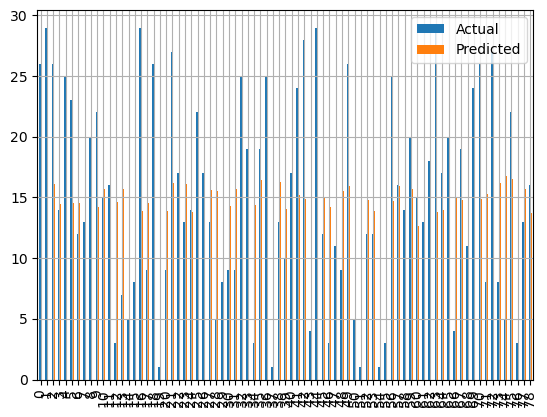

```python
actual_pred.plot(kind='bar')
plt.xticks(rotation=90)
plt.grid(which='major',linewidth='0.8')
plt.grid(which='minor',linewidth='0.8')
plt.show()
```

## Training and Testing Score of the Regression

```python
print("Training Score:",reg.score(x_train,y_train))
print("Testing Score:",reg.score(x_test,y_test))
```

```
Training Score: 0.01058387375253278
Testing Score: -0.004085856386989661
```

## Accuracy by Linear Regression

```python
print("Accuracy:",reg.score(x,y)*100)
```

```
Accuracy: 0.7778707489479508
```

# Decision Tree Classifier

```python
from sklearn.tree import DecisionTreeClassifier
```

```python
clf=DecisionTreeClassifier()
```

```python
clf.fit(x_train,y_train)
```

```
DecisionTreeClassifier()
```

```python
x_test
```

```
array([[9.5516e+04, 3.6800e+02, 1.0000e+02, 1.0000e+02, 1.0000e+02,
        8.0000e+00, 2.4000e+01],
       [4.7358e+04, 3.1700e+02, 1.0000e+02, 1.0000e+02, 1.0000e+02,
        2.1000e+01, 7.0000e+00],
       [2.2900e+04, 1.4900e+02, 1.0000e+02, 1.0000e+02, 1.0000e+02,
        1.7000e+01, 2.1000e+01],
       [3.5997e+04, 2.6000e+02, 1.0000e+02, 1.0000e+02, 1.0000e+02,
        4.0000e+00, 1.8000e+01],
       [8.4325e+04, 3.0800e+02, 1.0000e+02, 1.0000e+02, 1.0000e+02,
        1.1000e+01, 1.7000e+01],
       [4.9497e+04, 3.4800e+02, 1.0000e+02, 1.0000e+02, 1.0000e+02,
        1.6000e+01, 8.0000e+00],
       [5.0311e+04, 3.2500e+02, 1.0000e+02, 1.0000e+02, 1.0000e+02,
        1.9000e+01, 2.0000e+00],
       [1.3797e+04, 1.8300e+02, 1.0000e+02, 1.0000e+02, 1.0000e+02,
        2.1000e+01, 5.0000e+00],
       [8.5474e+04, 8.8000e+01, 1.0000e+02, 1.0000e+02, 1.0000e+02,
        6.0000e+00, 1.1000e+01],
       [3.9780e+04, 3.7100e+02, 1.0000e+02, 1.0000e+02, 1.0000e+02,
        1.5000e+01, 2.0000e+00],
       [7.0248e+04, 1.5800e+02, 1.0000e+02, 1.0000e+02, 1.0000e+02,
        2.2000e+01, 1.4000e+01],
       [3.7600e+04, 3.6700e+02, 1.0000e+02, 1.0000e+02, 1.0000e+02,
        1.2000e+01, 1.7000e+01],
       [1.3084e+04, 3.2900e+02, 1.0000e+02, 1.0000e+02, 1.0000e+02,
        1.0000e+00, 2.5000e+01],
       [2.0474e+04, 1.2900e+02, 1.0000e+02, 1.0000e+02, 1.0000e+02,
        1.3000e+01, 1.7000e+01],
       [6.1076e+04, 2.2000e+02, 1.0000e+02, 1.0000e+02, 1.0000e+02,
        1.9000e+01, 1.0000e+01],
       [3.6208e+04, 9.8000e+01, 1.0000e+02, 1.0000e+02, 1.0000e+02,
        1.4000e+01, 1.8000e+01],
       [7.7029e+04, 2.4700e+02, 1.0000e+02, 1.0000e+02, 1.0000e+02,
        1.1000e+01, 3.0000e+00],
       [1.0016e+04, 2.9100e+02, 1.0000e+02, 1.0000e+02, 1.0000e+02,
        9.0000e+00, 8.0000e+00],
       [5.5650e+04, 6.8000e+01, 1.0000e+02, 1.0000e+02, 1.0000e+02,
        2.5000e+01, 5.0000e+00],
       [3.2524e+04, 1.0000e+02, 1.0000e+02, 1.0000e+02, 1.0000e+02,
        1.1000e+01, 9.0000e+00],
```

[output cut: 103 more lines]

```
        2.0000e+01, 1.3000e+01],
       [5.4940e+04, 1.7000e+02, 1.0000e+02, 1.0000e+02, 1.0000e+02,
        1.6000e+01, 2.8000e+01],
       [1.5011e+04, 1.4300e+02, 1.0000e+02, 1.0000e+02, 1.0000e+02,
        1.5000e+01, 2.3000e+01],
       [2.7973e+04, 1.2500e+02, 1.0000e+02, 1.0000e+02, 1.0000e+02,
        2.1000e+01, 2.7000e+01],
       [7.9804e+04, 7.3000e+01, 1.0000e+02, 1.0000e+02, 1.0000e+02,
        2.3000e+01, 2.6000e+01],
       [1.5455e+04, 6.0000e+00, 1.0000e+02, 1.0000e+02, 1.0000e+02,
        2.0000e+00, 5.0000e+00],
       [2.3635e+04, 2.1000e+02, 1.0000e+02, 1.0000e+02, 1.0000e+02,
        2.4000e+01, 4.0000e+00],
       [6.5105e+04, 4.2000e+01, 1.0000e+02, 1.0000e+02, 1.0000e+02,
        2.0000e+00, 2.0000e+00]])
```

```python
y_test
```

```
array([26, 29, 26, 14, 25, 23, 12, 13, 20, 22, 15, 16,  3,  7,  5,  8, 29,
        9, 26,  1,  9, 27, 17, 13, 14, 22, 17, 13,  5,  8,  9,  9, 25, 19,
        3, 19, 25,  1, 13, 10, 17, 24, 28,  4, 29, 12,  3, 11,  9, 26,  5,
        1, 12, 12,  1,  3, 25, 16, 14, 20, 15, 13, 18, 29, 17, 20,  4, 19,
       11, 24, 26,  8, 27,  8,  5, 22,  3, 13, 16])
```

```python
y_pred2=clf.predict(x_test)
y_pred2
```

```
array([24,  9, 29, 10, 16,  4,  9,  9,  3, 28,  3, 13,  6, 27, 12, 16, 21,
        6, 29,  4, 27,  9, 26,  9, 18, 12, 23, 12,  3,  6, 23, 19,  9, 28,
        5, 25, 24, 24, 26, 21, 22,  1, 23, 28,  2,  2, 28, 20, 23,  6, 14,
        4, 29, 24, 13, 24,  9, 17,  6, 24, 26,  9, 28, 12,  3, 22,  9,  5,
       20, 22, 24, 16,  9,  9, 14, 13,  2,  9, 12])
```

## Mean Squared Error by DecisionTree Classifier

## R2_score by Decision Tree Classifier

```python
mse=mean_squared_error(y_test,y_pred2)
r2=r2_score(y_test,y_pred2)
print("Mean Squared Error:",mse)
print("R2_Score:",r2)
```

```
Mean Squared Error: 135.91139240506328
R2_Score: -0.9610278818143985
```

```python
cm=confusion_matrix(y_test,y_pred2)
print(cm)
```

```
[[0 0 0 2 0 0 0 0 0 0 0 0 1 0 0 0 0 0 0 0 0 0 0 1 0 0 0 0 0]
 [0 0 0 0 0 0 0 0 0 0 0 0 0 0 0 0 0 0 0 0 0 0 0 0 0 0 0 0 0]
 [0 1 0 0 1 1 0 0 0 0 0 0 0 0 0 0 0 0 0 0 0 0 0 1 0 0 0 1 0]
 [0 0 0 0 0 0 0 0 1 0 0 0 0 0 0 0 0 0 0 0 0 0 0 0 0 0 0 1 0]
 [0 0 1 0 0 0 0 0 0 0 0 1 0 2 0 0 0 0 0 0 0 0 0 0 0 0 0 0 0]
 [0 0 0 0 0 0 0 0 0 0 0 0 0 0 0 0 0 0 0 0 0 0 0 0 0 0 0 0 0]
 [0 0 0 0 0 0 0 0 0 0 0 0 0 0 0 0 0 0 0 0 0 0 0 0 0 0 1 0 0]
 [0 0 0 0 0 1 0 0 1 0 0 0 0 0 0 2 0 0 0 0 0 0 0 0 0 0 0 0 0]
 [0 0 0 0 0 1 0 0 0 0 0 0 0 0 0 0 0 0 1 0 0 0 2 0 0 0 1 0 0]
 [0 0 0 0 0 0 0 0 0 0 0 0 0 0 0 0 0 0 0 0 1 0 0 0 0 0 0 0 0]
 [0 0 0 0 0 0 0 0 0 0 0 0 0 0 0 0 0 0 0 2 0 0 0 0 0 0 0 0 0]
 [0 1 0 0 0 0 0 0 1 0 0 0 0 0 0 0 0 0 0 0 0 0 0 1 0 0 0 0 1]
 [0 0 0 0 0 0 0 0 4 0 0 1 0 0 0 0 0 0 0 0 0 0 0 0 0 1 0 0 0]
 [0 0 0 0 0 1 0 0 0 1 0 0 0 0 0 0 0 1 0 0 0 0 0 0 0 0 0 0 0]
 [0 0 1 0 0 0 0 0 0 0 0 0 0 0 0 0 0 0 0 0 0 0 0 0 0 1 0 0 0]
 [0 0 0 0 0 0 0 0 0 0 0 1 1 0 0 0 1 0 0 0 0 0 0 0 0 0 0 0 0]
 [0 0 1 0 0 0 0 0 0 0 0 0 0 0 0 0 0 0 0 0 0 1 1 0 0 1 0 0 0]
 [0 0 0 0 0 0 0 0 0 0 0 0 0 0 0 0 0 0 0 0 0 0 0 0 0 0 0 1 0]
 [0 0 0 0 1 0 0 0 0 0 0 0 0 0 0 0 0 0 0 0 0 0 0 0 1 0 0 1 0]
 [0 0 1 0 0 0 0 0 0 0 0 0 0 0 0 0 0 0 0 0 0 1 0 1 0 0 0 0 0]
 [0 0 0 0 0 0 0 0 0 0 0 0 0 0 0 0 0 0 0 0 0 0 0 0 0 0 0 0 0]
 [0 0 0 0 0 0 0 0 0 0 0 1 1 0 0 0 0 0 0 0 0 0 0 0 0 0 0 1 0]
 [0 0 0 1 0 0 0 0 0 0 0 0 0 0 0 0 0 0 0 0 0 0 0 0 0 0 0 0 0]
 [1 0 0 0 0 0 0 0 0 0 0 0 0 0 0 0 0 0 0 0 0 1 0 0 0 0 0 0 0]
 [0 0 0 0 0 0 0 0 2 0 0 0 0 0 0 1 0 0 0 0 0 0 0 1 0 0 0 0 0]
 [0 0 0 0 0 1 0 0 0 0 0 0 0 0 0 0 0 0 0 0 0 0 0 2 0 0 0 0 2]
 [0 0 0 0 0 0 0 0 2 0 0 0 0 0 0 0 0 0 0 0 0 0 0 0 0 0 0 0 0]
 [0 0 0 0 0 0 0 0 0 0 0 0 0 0 0 0 0 0 0 0 0 0 1 0 0 0 0 0 0]
 [0 1 0 0 0 0 0 0 1 0 0 1 0 0 0 0 0 0 0 0 1 0 0 0 0 0 0 0 0]]
```

[figure not shown]

```python
sns.heatmap(cm/np.sum(cm),annot=True,fmt='.2%')
```

```python
y_test=y_test.ravel()
y_pred2=y_pred2.ravel()
```

```python
actual_pred=pd.DataFrame({'Actual':y_test,'Predicted':y_pred2})
actual_pred
```

|  | Actual | Predicted |
| --- | --- | --- |
| 0 | 26 | 24 |
| 1 | 29 | 9 |
| 2 | 26 | 29 |
| 3 | 14 | 10 |
| 4 | 25 | 16 |
| ... | ... | ... |
| 74 | 5 | 14 |
| 75 | 22 | 13 |
| 76 | 3 | 2 |
| 77 | 13 | 9 |
| 78 | 16 | 12 |

79 rows × 2 columns

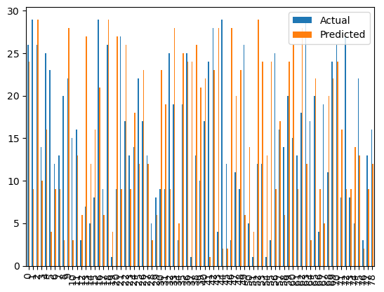

```python
actual_pred.plot(kind='bar')
plt.show()
```

## Training and Testing Score of the Regression

```python
print("Training Score:",clf.score(x_train,y_train))
print("Testing Score:",clf.score(x_test,y_test))
```

```
Training Score: 1.0
Testing Score: 0.0
```

## Accuracy by Decion Tree Classifier

```python
print("Accuracy:",clf.score(x,y)*100)
```

```
Accuracy: 79.79539641943734
```

## Classification Report:

```python
print(classification_report(y_test,y_pred2))
```

```
              precision    recall  f1-score   support

           1       0.00      0.00      0.00       4.0
           2       0.00      0.00      0.00       0.0
           3       0.00      0.00      0.00       5.0
           4       0.00      0.00      0.00       2.0
           5       0.00      0.00      0.00       4.0
           6       0.00      0.00      0.00       0.0
           7       0.00      0.00      0.00       1.0
           8       0.00      0.00      0.00       4.0
           9       0.00      0.00      0.00       5.0
          10       0.00      0.00      0.00       1.0
          11       0.00      0.00      0.00       2.0
          12       0.00      0.00      0.00       4.0
          13       0.00      0.00      0.00       6.0
```

[output cut: 20 more lines]